# Data Analysis

### R preparation

```r
if (!requireNamespace("pacman", quietly = TRUE)) {
  install.packages("pacman")
}
library("pacman")
#already load:
p_load(tidyverse, here, viridis, cowplot, MPTinR, scales, ggh4x, patchwork, irr)

df_judgment <- read.csv("data_judgment.csv") |>
  mutate(frequency_condition =
           case_when(condition %in% c("A", "B") ~ "20-learning-trial",
                     condition %in% c("C", "D") ~ "40-learning-trial",
                     TRUE ~ NA)) |>

 mutate(part = recode(part, "veggie" = "edge", "fruit" = "mid"))

subsample_ids <- readRDS("subsample_ids.rds")
```

### Wiki

Re-name the stimuli for the convenience of coding:

banana (from box A): A  
cherry (from box A): B  
orange (form box B): C  
strawberry(from box B): D  
carrot(from box C): E  
tomato(from box C): F  
broccoli(from box D): G  
radish(from box D): H  
A&B are a pair of complementary mid-events, C&D are a pair of complementary mid-events,  
E&F are a pair of complementary edge-events, G&H are a pair of complementary edge-events

Liu et al. (2025) found illogical rankings. We wanted to know if illogical rankings occur after probability learning (in the learning environment). In the learning phase, participants learnt the probability of two pairs of complementary events {$A_1$, $\neg A_1$ $A_2$, $\neg A_2$}. Rankings were elicited from participants in two ways. In the first way, each participant provided rankings for stimuli of the same type (learned in the same block) simultaneously; that is, each participant provided a ranking for the mid-event set simultaneously, and then a ranking for the edge-event set simultaneously, resulting in two rankings per participant. In the second way, participants did pairwise comparisons of stimuli of the same type (learned in the same block). For each set of four stimuli of the same type, the participant did the pairwise comparison of every possible combination twice. For example, for the event set {$A_1$, $\neg A_1$ $A_2$, $\neg A_2$}, participants compared $A_1$versus $\neg A_1$ twice, compared $A_1$ versus $A_2$ twice, compared $A_1$ versus $\neg A_2$ twice, compared $\neg A_1$ versus $A_2$ twice, compared $\neg A_1$ versus$\neg A_2$ twice and compared $A_2$ versus $\neg A_2$ twice. A ranking was elicited from the pairwise comparison results for the fruit (mid-event) set, and a ranking was elicited from the pairwise comparison results for the vegetable (edge-event) set, again resulting in two rankings per participant.

### Data preparation:

```r
logical_patterns <- c("A\\|C\\|D\\|B",
                      "A\\|D\\|C\\|B",
                      "B\\|C\\|D\\|A",
                      "B\\|D\\|C\\|A",
                      "C\\|A\\|B\\|D",
                      "C\\|B\\|A\\|D",
                      "D\\|A\\|B\\|C",
                      "D\\|B\\|A\\|C",
                      "A\\|CD\\|B\\|",
                      "B\\|CD\\|A\\|",
                      "C\\|AB\\|D\\|",
                      "D\\|AB\\|C\\|",
                      "AC\\|BD\\|\\|",
                      "AD\\|BC\\|\\|",
                      "BC\\|AD\\|\\|",
                      "BD\\|AC\\|\\|",
                      "ABCD\\|\\|\\|",
                      "E\\|G\\|H\\|F",
                      "E\\|H\\|G\\|F",
                      "F\\|G\\|H\\|E",
                      "F\\|H\\|G\\|E",
                      "G\\|E\\|F\\|H",
                      "G\\|F\\|E\\|H",
                      "H\\|E\\|F\\|G",
                      "H\\|F\\|E\\|G",
                      "E\\|GH\\|F\\|",
                      "F\\|GH\\|E\\|",
                      "G\\|EF\\|H\\|",
                      "H\\|EF\\|G\\|",
                      "EG\\|FH\\|\\|",
                      "EH\\|FG\\|\\|",
                      "FG\\|EH\\|\\|",
                      "FH\\|EG\\|\\|",
                      "EFGH\\|\\|\\|")

stacked_patterns <- c("A\\|B\\|C\\|D", "A\\|B\\|D\\|C",
                      "B\\|A\\|C\\|D", "B\\|A\\|D\\|C",
                      "C\\|D\\|A\\|B", "C\\|D\\|B\\|A",
                      "D\\|C\\|A\\|B", "D\\|C\\|B\\|A",
                      "AB\\|C\\|D\\|", "AB\\|D\\|C\\|",
                      "CD\\|A\\|B\\|", "CD\\|B\\|A\\|",
                      "A\\|B\\|CD\\|", "B\\|A\\|CD\\|",
                      "C\\|D\\|AB\\|", "D\\|C\\|AB\\|",
                      "AB\\|CD\\|\\|", "CD\\|AB\\|\\|",
                      "E\\|F\\|G\\|H", "E\\|F\\|H\\|G",
                      "F\\|E\\|G\\|H", "F\\|E\\|H\\|G",
                      "G\\|H\\|E\\|F", "G\\|H\\|F\\|E",
                      "H\\|G\\|E\\|F", "H\\|G\\|F\\|E",
                      "EF\\|G\\|H\\|", "EF\\|H\\|G\\|",
                      "GH\\|E\\|F\\|", "GH\\|F\\|E\\|",
                      "E\\|F\\|GH\\|", "F\\|E\\|GH\\|",
                      "G\\|H\\|EF\\|", "H\\|G\\|EF\\|",
                      "EF\\|GH\\|\\|", "GH\\|EF\\|\\|")

interlaced_patterns <- c("A\\|C\\|B\\|D", "A\\|D\\|B\\|C",
                         "B\\|C\\|A\\|D", "B\\|D\\|A\\|C",
                         "C\\|A\\|D\\|B", "C\\|B\\|D\\|A",
                         "D\\|A\\|C\\|B", "D\\|B\\|C\\|A",
                         "AC\\|B\\|D\\|", "AC\\|D\\|B\\|",
                         "AD\\|B\\|C\\|", "AD\\|C\\|B\\|",
                         "BC\\|A\\|D\\|", "BC\\|D\\|A\\|",
                         "BD\\|A\\|C\\|",  "BD\\|C\\|A\\|",
                         "A\\|C\\|BD\\|",  "A\\|D\\|BC\\|",
                         "B\\|C\\|AD\\|",  "B\\|D\\|AC\\|",
                         "C\\|A\\|BD\\|",  "C\\|B\\|AD\\|",
                         "D\\|A\\|BC\\|",  "D\\|B\\|AC\\|",
                         "E\\|G\\|F\\|H", "E\\|H\\|F\\|G",
                         "F\\|G\\|E\\|H", "F\\|H\\|E\\|G",
                         "G\\|E\\|H\\|F", "G\\|F\\|H\\|E",
                         "H\\|E\\|G\\|F", "H\\|F\\|G\\|E",
                         "EG\\|F\\|H\\|", "EG\\|H\\|F\\|",
                         "EH\\|F\\|G\\|", "EH\\|G\\|F\\|",
                         "FG\\|E\\|H\\|", "FG\\|H\\|E\\|",
                         "FH\\|E\\|G\\|",  "FH\\|G\\|E\\|",
                         "E\\|G\\|FH\\|",  "E\\|H\\|FG\\|",
                         "F\\|G\\|EH\\|",  "F\\|H\\|EG\\|",
                         "G\\|E\\|FH\\|",  "G\\|F\\|EH\\|",
                         "H\\|E\\|FG\\|",  "H\\|F\\|EG\\|")

other_patterns <- c("A\\|BC\\|D\\|",
                    "A\\|BD\\|C\\|",
                    "B\\|AC\\|D\\|",
                    "B\\|AD\\|C\\|",
                    "C\\|BD\\|A\\|",
                    "C\\|AD\\|B\\|",
                    "D\\|BC\\|A\\|",
                    "D\\|AC\\|B\\|",
                    "ACD\\|B\\|\\|",
                    "BCD\\|A\\|\\|",
                    "ABC\\|D\\|\\|",
                    "ABD\\|C\\|\\|",
                    "A\\|BCD\\|\\|",
                    "B\\|ACD\\|\\|",
                    "C\\|ABD\\|\\|",
                    "D\\|ABC\\|\\|",
                    "E\\|FG\\|H\\|",
                    "E\\|FH\\|G\\|",
                    "F\\|EG\\|H\\|",
                    "F\\|EH\\|G\\|",
                    "G\\|FH\\|E\\|",
                    "G\\|EH\\|F\\|",
                    "H\\|FG\\|E\\|",
                    "H\\|EG\\|F\\|",
                    "EGH\\|F\\|\\|",
                    "FGH\\|E\\|\\|",
                    "EFG\\|H\\|\\|",
                    "EFH\\|G\\|\\|",
                    "E\\|FGH\\|\\|",
                    "F\\|EGH\\|\\|",
                    "G\\|EFH\\|\\|",
                    "H\\|EFG\\|\\|")
```

#### directly-provided rankings

```r
ranking_direct <- df_judgment  |>
  filter(sender == "Ranking_Screen") |>
  select(id,
         condition,
         part,
         order_one_contents_options,
         order_two_contents_options,
         order_three_contents_options,
         order_four_contents_options)  |>
  unique()

sort_letters <- function(strings) {
  sapply(strings, function(x) paste(sort(unlist(strsplit(x, ""))), collapse = ""))
}
#Alphabetically sort the letters within each cell of the columns "order_one_contents_options", "order_two_contents_options", "order_three_contents_options", "order_four_contents_options"
#for example convert "DBC" to "BCD"

columns_to_sort <- c("order_one_contents_options", "order_two_contents_options",
                     "order_three_contents_options", "order_four_contents_options")

ranking_direct[columns_to_sort] <- lapply(ranking_direct[columns_to_sort], sort_letters)

ranking_direct$concatenated_ranking <- apply(ranking_direct[, columns_to_sort], 1, paste, collapse = "|")

ranking_direct <- ranking_direct |>
  mutate(provided_logical = as.integer(sapply(concatenated_ranking, function(x) {
    any(sapply(logical_patterns, function(pattern) grepl(pattern, x)))
  })))  |>
  mutate(provided_stacked = as.integer(sapply(concatenated_ranking, function(x) {
    any(sapply(stacked_patterns, function(pattern) grepl(pattern, x)))
  }))) |>
  mutate(provided_interlaced = as.integer(sapply(concatenated_ranking, function(x) {
    any(sapply(interlaced_patterns, function(pattern) grepl(pattern, x)))
  })))  |>
  mutate(provided_other = as.integer(sapply(concatenated_ranking, function(x) {
    any(sapply(other_patterns, function(pattern) grepl(pattern, x)))
  }))) |>
  select(id, condition, part, provided_ranking = concatenated_ranking,
         provided_logical,
         provided_stacked,
         provided_interlaced,
         provided_other) |>
  mutate(provided_ranking_category = case_when(
    provided_logical == 1 ~ "Logical",
    provided_stacked == 1 ~ "Stacked",
    provided_interlaced == 1 ~ "Interlaced",
    provided_other == 1 ~ "Other"
  )) |>
  mutate(frequency_condition =
           case_when(condition %in% c("A", "B") ~ "20-learning-trial",
                     condition %in% c("C", "D") ~ "40-learning-trial",)) |>
  mutate(check_sum = provided_logical + provided_stacked + provided_interlaced + provided_other)

ranking_direct$provided_ranking_category <- factor(ranking_direct$provided_ranking_category,
                                              levels = c( "Logical","Stacked",
                                                          "Interlaced","Other"),
                                              labels = c("Logical", "Stacked", "Interlaced", "Other"))
```

#### rankings derived from comparisons

```r
elicit <- df_judgment |> filter (sender == "show_choice") |>
  select(id, condition, part, compare1, compare2, response,
         response_action) |>
  mutate(response = case_when(
    response == "compare1" ~ compare1,
    response == "compare2" ~ compare2,
    TRUE ~ NA
  )) |>
  group_by(id, condition, part) |>
  count(response) |>
  ungroup()

# Define the complete set of response options
response <- c('A', 'B', 'C', 'D',
              'E', 'F', 'G', 'H')

all_options <- expand.grid(id = unique(df_judgment$id),
                           response= response)

ranking_comparison <- all_options |>
  left_join(elicit, by = c("id", "response")) |> #add options that have never been selected in pairwise comparisons to the “response” column.
  mutate(n = ifelse(is.na(n), 0, n)) |>
  group_by(id) |>
  fill(condition, .direction = "downup") |>
  ungroup() |>
  mutate(
    part = case_when(
      response %in% c("A", "B", "C", "D") ~ "mid",
      response %in% c("E", "F", "G", "H") ~ "edge",
      TRUE                                ~ NA_character_
    )) |>
  group_by(id, part) |>
  mutate(rank = dense_rank(desc(n))) |>
  select(-n) |>
  pivot_wider(
    names_from  = rank,
    values_from = response
  ) |>
  select(
    id, condition, part,
    order_one   = `1`,
    order_two   = `2`,
    order_three = `3`,
    order_four  = `4`
  ) |>
  mutate(
    across(
      starts_with("order"),
      ~ map_chr(.x, ~ paste(.x, collapse = ","))
    )
  ) |>
  ungroup()
ranking_comparison$concatenated_ranking <- apply(ranking_comparison[, c("order_one",
                                                "order_two",
                                                "order_three",
                                                "order_four")], 1, paste, collapse = "|")

ranking_comparison$concatenated_ranking <- gsub(",| ", "", ranking_comparison$concatenated_ranking) #replace "A, B, C" with "ABC"

ranking_comparison <- ranking_comparison |>
  mutate(elicited_logical = as.integer(sapply(concatenated_ranking, function(x) {
    any(sapply(logical_patterns, function(pattern) grepl(pattern, x)))
  }))) |>
  mutate(elicited_stacked = as.integer(sapply(concatenated_ranking, function(x) {
    any(sapply(stacked_patterns, function(pattern) grepl(pattern, x)))
  })))|>
  mutate(elicited_interlaced = as.integer(sapply(concatenated_ranking, function(x) {
    any(sapply(interlaced_patterns, function(pattern) grepl(pattern, x)))
  }))) |>
  mutate(elicited_other = as.integer(sapply(concatenated_ranking, function(x) {
    any(sapply(other_patterns, function(pattern) grepl(pattern, x)))
  }))) |>
  mutate(check_sum = elicited_logical + elicited_stacked + elicited_interlaced + elicited_other) |>
  mutate(frequency_condition = case_when(
    condition %in% c("A", "B") ~ "20-learning-trial",
    condition %in% c("C", "D") ~ "40-learning-trial",
    TRUE ~ NA_character_
  )) |>
  select(id, condition, frequency_condition, part,
         elicited_ranking = concatenated_ranking,
         elicited_logical,
         elicited_stacked,
         elicited_interlaced,
         elicited_other,
         check_sum) |>
  mutate(elicited_ranking_category = case_when(
    elicited_logical == 1 ~ "Logical",
    elicited_stacked == 1 ~ "Stacked",
    elicited_interlaced == 1 ~ "Interlaced",
    elicited_other == 1 ~ "Other"
  ))

ranking_comparison$elicited_ranking_category <- factor(ranking_comparison$elicited_ranking_category,
                                                   levels = c( "Logical","Stacked",
                                                               "Interlaced","Other"),
                                                   labels = c("Logical", "Stacked",
                                                              "Interlaced", "Other"))
```

### Plot

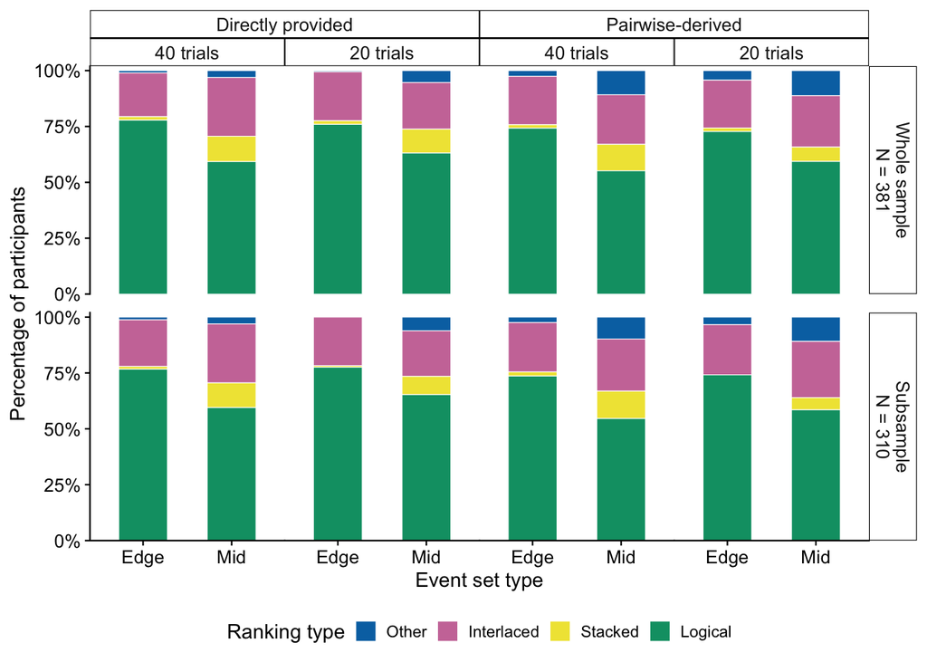

```r
ranking_direct_subsample <- ranking_direct |>
  filter(id %in% subsample_ids)

ranking_comparison_subsample <- ranking_comparison |>
  filter(id %in% subsample_ids)

prep <- function(df, catcol, source, sample) {
  df |>
    transmute(id, part, frequency_condition,
              ranking_category = {{ catcol }},
              ranking_source = source,
              sample = sample)
}

ranking_all <- bind_rows(
  prep(ranking_direct,               provided_ranking_category, "Directly provided", "Whole sample"),
  prep(ranking_comparison,           elicited_ranking_category, "Pairwise-derived",  "Whole sample"),
  prep(ranking_direct_subsample,     provided_ranking_category, "Directly provided", "Subsample"),
  prep(ranking_comparison_subsample, elicited_ranking_category, "Pairwise-derived",  "Subsample")
) |>
  mutate(
    sample              = factor(sample, levels = c("Whole sample", "Subsample")),
    ranking_source      = factor(ranking_source,
                                 levels = c("Directly provided", "Pairwise-derived")),
    frequency_condition = factor(frequency_condition,
                                 levels = c("40-learning-trial", "20-learning-trial"),
                                 labels = c("40 trials", "20 trials")),
    part                = factor(part, levels = c("edge", "mid"),
                                 labels = c("Edge", "Mid")),
    # reversed so Logical anchors the bottom of each stack
    ranking_category    = factor(ranking_category,
                                 levels = c("Other", "Interlaced", "Stacked", "Logical"))
  ) |>
  # row label carrying N, ordered to follow `sample`
  group_by(sample) |>
  mutate(sample_lab = paste0(sample, "\nN = ", n_distinct(id))) |>
  ungroup() |>
  mutate(sample_lab = fct_reorder(sample_lab, as.integer(sample)))

theme_apa <- theme_classic(base_size = 11) +
  theme(
    axis.text        = element_text(size = 10, colour = "black"),
    axis.line        = element_line(colour = "black", linewidth = 0.4),
    axis.ticks       = element_line(colour = "black", linewidth = 0.4),
    strip.background = element_rect(fill = NA, colour = "black", linewidth = 0.4),
    strip.text.x     = element_text(size = 10, margin = margin(3, 3, 3, 3)),
    strip.text.y     = element_text(size = 10, angle = -90,
                                    margin = margin(3, 3, 3, 3)),
    legend.position  = "bottom",
    legend.key.size  = unit(0.8, "lines"),
    panel.spacing.x  = unit(0, "lines"),
    panel.spacing.y  = unit(0.7, "lines")
  )

p_apa <- ggplot(ranking_all, aes(x = part, fill = ranking_category)) +
  geom_bar(position = "fill", width = 0.55, colour = "white", linewidth = 0.2) +
  facet_nested(sample_lab ~ ranking_source + frequency_condition) +
  scale_y_continuous(labels = percent_format(accuracy = 1),
                     expand = expansion(mult = c(0, 0.02))) +
  scale_fill_manual(
    name   = "Ranking type",
    values = c(Logical = "#009E73", Stacked = "#F0E442",
               Interlaced = "#CC79A7", Other = "#0072B2"),
    breaks = c("Logical", "Stacked", "Interlaced", "Other")
  ) +
  guides(fill = guide_legend(reverse = TRUE, nrow = 1)) +
  labs(x = "Event set type", y = "Percentage of participants") +
  theme_apa

p_apa
```

```r
ggsave("judgment.pdf", p_apa, width = 7, height = 5.5, units = "in")
```

### MPT analysis

```r
# Quick checks: every ranking falls in exactly one category,
# and there is exactly one ranking per participant and event set
stopifnot(all(ranking_direct$check_sum == 1))
stopifnot(all(ranking_comparison$check_sum == 1))
stopifnot(!any(duplicated(ranking_direct[, c("id", "part")])))
stopifnot(!any(duplicated(ranking_comparison[, c("id", "part")])))

count_cells <- function(df, logical, other, stacked, interlaced) {
  df |>
    group_by(frequency_condition, part) |>
    summarise(logical    = sum({{ logical }}),
              other      = sum({{ other }}),
              stacked    = sum({{ stacked }}),
              interlaced = sum({{ interlaced }}),
              n          = n(),
              .groups    = "drop")
}

counts_direct <- count_cells(ranking_direct,
                             provided_logical, provided_other,
                             provided_stacked, provided_interlaced)

counts_comparison <- count_cells(ranking_comparison,
                                 elicited_logical, elicited_other,
                                 elicited_stacked, elicited_interlaced)

counts_direct
```

```
# A tibble: 4 × 7
  frequency_condition part  logical other stacked interlaced     n
  <chr>               <chr>   <int> <int>   <int>      <int> <int>
1 20-learning-trial   edge      142     1       3         41   187
2 20-learning-trial   mid       118    10      20         39   187
3 40-learning-trial   edge      151     2       3         38   194
4 40-learning-trial   mid       115     6      22         51   194
```

```r
counts_comparison
```

```
# A tibble: 4 × 7
  frequency_condition part  logical other stacked interlaced     n
  <chr>               <chr>   <int> <int>   <int>      <int> <int>
1 20-learning-trial   edge      136     8       3         40   187
2 20-learning-trial   mid       111    21      12         43   187
3 40-learning-trial   edge      144     5       3         42   194
4 40-learning-trial   mid       107    21      23         43   194
```

```r
# prepare data in the format that MPTinR wants
one_tree <- function(counts, cond, set) {
  row <- counts |> filter(frequency_condition == cond, part == set)
  c(row$logical, row$other, row$stacked, row$interlaced)
}

data_vector <- function(counts) {
  c(one_tree(counts, "20-learning-trial", "edge"),   # tree 1: edge20
    one_tree(counts, "20-learning-trial", "mid"),    # tree 2: mid20
    one_tree(counts, "40-learning-trial", "edge"),   # tree 3: edge40
    one_tree(counts, "40-learning-trial", "mid"))    # tree 4: mid40
}

data_direct     <- data_vector(counts_direct)
data_comparison <- data_vector(counts_comparison)
data_direct
```

```
 [1] 142   1   3  41 118  10  20  39 151   2   3  38 115   6  22  51
```

```r
data_comparison
```

```
 [1] 136   8   3  40 111  21  12  43 144   5   3  42 107  21  23  43
```

```r
# ---------------------- The preregistered four-tree model
model_unrestricted <- c(
  # tree 1: edge event set, 20 learning trials
  "le20",
  "(1-le20)*oe20",
  "(1-le20)*(1-oe20)*se20",
  "(1-le20)*(1-oe20)*(1-se20)",
  "",
  # tree 2: mid event set, 20 learning trials
  "lm20",
  "(1-lm20)*om20",
  "(1-lm20)*(1-om20)*sm20",
  "(1-lm20)*(1-om20)*(1-sm20)",
  "",
  # tree 3: edge event set, 40 learning trials
  "le40",
  "(1-le40)*oe40",
  "(1-le40)*(1-oe40)*se40",
  "(1-le40)*(1-oe40)*(1-se40)",
  "",
  # tree 4: mid event set, 40 learning trials
  "lm40",
  "(1-lm40)*om40",
  "(1-lm40)*(1-om40)*sm40",
  "(1-lm40)*(1-om40)*(1-sm40)"
)

model_file <- tempfile(fileext = ".model")
writeLines(model_unrestricted, model_file)

check.mpt(model_file)   # expect: 4 trees, 16 categories, 12 parameters
```

```
$probabilities.eq.1
[1] TRUE

$n.trees
[1] 4

$n.model.categories
[1] 16

$n.independent.categories
[1] 12

$n.params
[1] 12

$parameters
 [1] "le20" "le40" "lm20" "lm40" "oe20" "oe40" "om20" "om40" "se20" "se40"
[11] "sm20" "sm40"
```

```r
fit_direct     <- fit.mpt(data_direct, model_file)
```

```
Presenting the best result out of 5 minimization runs.
```

```
[1] "Model fitting begins at 2026-09-28 11:47:25.505199"
[1] "Model fitting stopped at 2026-09-28 11:47:25.55087"
Time difference of 0.04567099 secs
```

```r
fit_direct
```

```
$goodness.of.fit
  Log.Likelihood G.Squared df p.value
1      -626.8602         0  0       1

$information.criteria
  AIC      BIC
1  24 79.63136

$model.info
  rank.fisher n.parameters n.independent.categories
1          12           12                       12

$parameters
      estimates   lower.conf upper.conf
le20 0.75935829  0.698089949 0.82062663
le40 0.77835052  0.719902712 0.83679832
lm20 0.63101604  0.561856641 0.70017544
lm40 0.59278351  0.523646914 0.66192010
oe20 0.02222222 -0.020845872 0.06529032
oe40 0.04651163 -0.016432082 0.10945534
om20 0.14492754  0.061865904 0.22798917
om40 0.07594937  0.017531660 0.13436707
se20 0.06818182 -0.006295089 0.14265873
se40 0.07317073 -0.006541457 0.15288292
sm20 0.33898305  0.218196835 0.45976927
sm40 0.30136986  0.196110623 0.40662910

$data
$data$observed
     [,1] [,2] [,3] [,4] [,5] [,6] [,7] [,8] [,9] [,10] [,11] [,12] [,13] [,14]
[1,]  142    1    3   41  118   10   20   39  151     2     3    38   115     6
     [,15] [,16]
[1,]    22    51

$data$predicted
     [,1] [,2] [,3] [,4] [,5] [,6] [,7] [,8] [,9] [,10] [,11] [,12] [,13] [,14]
[1,]  142    1    3   41  118   10   20   39  151     2     3    38   115     6
     [,15] [,16]
[1,]    22    51


$fitting.runs
          Min.   1st Qu.    Median      Mean   3rd Qu.      Max.
[1,] -626.8602 -626.8602 -626.8602 -626.8602 -626.8602 -626.8602
```

```r
fit_comparison <- fit.mpt(data_comparison, model_file)
```

```
Presenting the best result out of 5 minimization runs.
```

```
[1] "Model fitting begins at 2026-09-28 11:47:25.558309"
[1] "Model fitting stopped at 2026-09-28 11:47:25.589224"
Time difference of 0.03091502 secs
```

```r
fit_comparison
```

```
$goodness.of.fit
  Log.Likelihood G.Squared df p.value
1      -704.7588         0  0       1

$information.criteria
  AIC      BIC
1  24 79.63136

$model.info
  rank.fisher n.parameters n.independent.categories
1          12           12                       12

$parameters
      estimates   lower.conf upper.conf
le20 0.72727273  0.663440467  0.7911050
le40 0.74226804  0.680720353  0.8038157
lm20 0.59358289  0.523185918  0.6639799
lm40 0.55154639  0.481562674  0.6215301
oe20 0.15686275  0.057053206  0.2566723
oe40 0.10000000  0.016845771  0.1831542
om20 0.27631579  0.175780463  0.3768511
om40 0.24137931  0.151460443  0.3312982
se20 0.06976744 -0.006376618  0.1459115
se40 0.06666667 -0.006214379  0.1395477
sm20 0.21818182  0.109030519  0.3273331
sm40 0.34848485  0.233529195  0.4634405

$data
$data$observed
     [,1] [,2] [,3] [,4] [,5] [,6] [,7] [,8] [,9] [,10] [,11] [,12] [,13] [,14]
[1,]  136    8    3   40  111   21   12   43  144     5     3    42   107    21
     [,15] [,16]
[1,]    23    43

$data$predicted
     [,1] [,2] [,3] [,4] [,5] [,6] [,7] [,8] [,9] [,10] [,11] [,12] [,13] [,14]
[1,]  136    8    3   40  111   21   12   43  144     5     3    42   107    21
     [,15] [,16]
[1,]    23    43


$fitting.runs
          Min.   1st Qu.    Median      Mean   3rd Qu.      Max.
[1,] -704.7588 -704.7588 -704.7588 -704.7588 -704.7588 -704.7588
```

```r
# Because the model is saturated, every parameter is simply an observed
# proportion:
#   l = logical / n
#   O = other   / (n - logical)
#   S = stacked / (n - logical - other)
# so exact (Clopper-Pearson) 95% CIs come from binom.test().
# MPTinR's own CIs are Wald intervals and go below 0 for small parameters
# (e.g. oe20, oe40)

exact_ci_table <- function(counts) {
  out <- data.frame()
  for (i in 1:nrow(counts)) {
    r      <- counts[i, ]
    suffix <- paste0(ifelse(r$part == "edge", "e", "m"),
                     ifelse(r$frequency_condition == "20-learning-trial", "20", "40"))
    x <- c(r$logical, r$other,          r$stacked)
    n <- c(r$n,       r$n - r$logical,  r$n - r$logical - r$other)
    for (j in 1:3) {
      ci  <- binom.test(x[j], n[j])$conf.int
      out <- rbind(out, data.frame(
        parameter   = paste0(c("l", "o", "s")[j], suffix),
        numerator   = x[j],
        denominator = n[j],
        estimate    = x[j] / n[j],
        ci_lower    = ci[1],
        ci_upper    = ci[2]))
    }
  }
  out |> mutate(across(c(estimate, ci_lower, ci_upper), ~ round(.x, 3)))
}

ci_direct     <- exact_ci_table(counts_direct)
ci_comparison <- exact_ci_table(counts_comparison)

ci_direct
```

```
   parameter numerator denominator estimate ci_lower ci_upper
1       le20       142         187    0.759    0.692    0.819
2       oe20         1          45    0.022    0.001    0.118
3       se20         3          44    0.068    0.014    0.187
4       lm20       118         187    0.631    0.558    0.700
5       om20        10          69    0.145    0.072    0.250
6       sm20        20          59    0.339    0.221    0.474
7       le40       151         194    0.778    0.713    0.835
8       oe40         2          43    0.047    0.006    0.158
9       se40         3          41    0.073    0.015    0.199
10      lm40       115         194    0.593    0.520    0.663
11      om40         6          79    0.076    0.028    0.158
12      sm40        22          73    0.301    0.199    0.420
```